# P&S-2022: Lab assignment 2

Dominika Petrus, Nazar Pasichnyk, Daryna Onopriienko

## General comments and instructions

- Complete solution will give you **4 points** (working code with explanations + oral defense). Submission deadline **November 1, 2023, 22:00**
- The report must be prepared as an *R notebook*; you must submit to **cms** both the source *R notebook* **and** the generated html file
- At the beginning of the notebook, provide a work-breakdown structure estimating efforts of each team member
- For each task, include
  - problem formulation and discussion (what is a reasonable answer to discuss);
  - the corresponding $\mathbf{R}$ code with comments (usually it is just a couple of lines long);
  - the statistics obtained (like sample mean or anything else you use to complete the task) as well as histograms etc to illustrate your findings;
  - justification of your solution (e.g. refer to the corresponding theorems from probability theory);
  - conclusions (e.g. how reliable your answer is, does it agree with common sense expectations etc)
- The **team id number** referred to in tasks is the **two-digit** ordinal number of your team on the list. Include the line **set.seed(team id number)** at the beginning of your code to make your calculations reproducible. Also observe that the answers **do** depend on this number!
- Take into account that not complying with these instructions may result in point deduction regardless of whether or not your implementation is correct.

## Work Breakdown Structure

- Daryna Onopriienko: Task 1
- Nazar Pasichnyk: Task 2
- Dominika Petrus: Task 3 and 4

```r
set.seed(12)
```

### Task 1

#### In this task, we discuss the $[7,4]$ Hamming code and investigate its reliability. That coding system can correct single errors in the transmission of $4$-bit messages and proceeds as follows:

- given a message $\mathbf{m} = (a_1 a_2 a_3 a_4)$, we first encode it to a $7$-bit *codeword* $\mathbf{c} = \mathbf{m}G = (x_1 x_2 x_3 x_4 x_5 x_6 x_7)$, where $G$ is a $4\times 7$ *generator* matrix
- the codeword $\mathbf{c}$ is transmitted, and $\mathbf{r}$ is the received message
- $\mathbf{r}$ is checked for errors by calculating the *syndrome vector* $\mathbf{z} := \mathbf{r} H$, for a $7 \times 3$ *parity-check* matrix $H$
- if a single error has occurred in $\mathbf{r}$, then the binary $\mathbf{z} = (z_1 z_2 z_3)$ identifies the wrong bit no. $z_1 + 2 z_2 + 4z_3$; thus $(0 0 0)$ shows there was no error (or more than one), while $(1 1 0 )$ means the third bit (or more than one) got corrupted
- if the error was identified, then we flip the corresponding bit in $\mathbf{r}$ to get the corrected $\mathbf{r}^* = (r_1 r_2 r_3 r_4 r_5 r_6 r_7)$;
- the decoded message is then $\mathbf{m}^*:= (r_3r_5r_6r_7)$.

#### The **generator** matrix $G$ and the **parity-check** matrix $H$ are given by

$$G :=
\begin{pmatrix}
1 & 1 & 1 & 0 & 0 & 0 & 0 \\
1 & 0 & 0 & 1 & 1 & 0 & 0 \\
0 & 1 & 0 & 1 & 0 & 1 & 0 \\
1 & 1 & 0 & 1 & 0 & 0 & 1 \\
\end{pmatrix},
\qquad
H^\top := \begin{pmatrix}
1 & 0 & 1 & 0 & 1 & 0 & 1 \\
0 & 1 & 1 & 0 & 0 & 1 & 1 \\
0 & 0 & 0 & 1 & 1 & 1 & 1
\end{pmatrix}$$

#### Assume that each bit in the transmission $\mathbf{c} \mapsto \mathbf{r}$ gets corrupted independently of the others with probability $p = \mathtt{id}/100$, where $\mathtt{id}$ is your team number. Your task is the following one.

1. Simulate the encoding-transmission-decoding process $N$ times and find the estimate $\hat p$ of the probability $p^*$ of correct transmission of a single message $\mathbf{m}$. Comment why, for large $N$, $\hat p$ is expected to be close to $p^*$.
2. By estimating the standard deviation of the corresponding indicator of success by the standard error of your sample and using the CLT, predict the interval $(p^*-\varepsilon, p^* + \varepsilon)$, in which the estimate $\hat p$ falls with probability at least $0.95$.
3. What choice of $N$ guarantees that $\varepsilon \le 0.03$?
4. Draw the histogram of the number $k = 0,1,2,3,4$ of errors while transmitting a $4$-digit binary message. Do you think it is one of the known distributions?

#### You can (but do not have to) use the chunks we prepared for you

#### First, we set the **id** of the team and define the probability $p$ and the generator and parity-check matrices $G$ and $H$

```r
# your team id number
                          ###
id <- 12                  ### Change to the correct id!
                          ###
set.seed(id)
p <- id/100
# matrices G and H
G <- matrix(c(1, 1, 1, 0, 0, 0, 0,
        1, 0, 0, 1, 1, 0, 0,
        0, 1, 0, 1, 0, 1, 0,
        1, 1, 0, 1, 0, 0, 1), nrow = 4, byrow = TRUE)
H <- t(matrix(c(1, 0, 1, 0, 1, 0, 1,
        0, 1, 1, 0, 0, 1, 1,
        0, 0, 0, 1, 1, 1, 1), nrow = 3, byrow = TRUE))
# cat("The matrix G is: \n")
#G
#cat("The matrix H is: \n")
#H
#cat("The product GH must be zero: \n")
#(G%*%H) %%2
```

#### Next, generate the messages

```r
# generate N messages

message_generator <- function(N) {
  matrix(sample(c(0,1), 4*N, replace = TRUE), nrow = N)
}
messages <- message_generator(100)
codewords <- (messages %*% G) %% 2

encode <- function(messages) {
  (messages %*% G) %% 2
}

add_noise <- function(codewords, p) {
  E <- matrix(rbinom(length(codewords), size=1, prob=p), nrow = nrow(codewords))
  (codewords + E) %% 2
}

syndrome_vec <- function(r_row) {
  as.integer((r_row %*% H) %% 2)
}

correct_errored <- function(r_row) {
  z <- syndrome_vec(r_row)
  pos <- z[1] + 2*z[2] + 4*z[3]
  if (pos > 0)
    r_row[pos] <- (r_row[pos] + 1) %% 2
  r_row
}


decode_message <- function(r_star) {
  c(r_star[3], r_star[5], r_star[6], r_star[7])
}
```

Part 1. Simulating the encoding-transmission-decoding process and estimate $\hat p$

```r
simulate_hamming <- function(N, p) {
  messages  <- message_generator(N)
  codewords <- encode(messages)
  received  <- add_noise(codewords, p)
  corrected <- t(apply(received, 1, correct_errored))
  decoded   <- t(apply(corrected, 1, decode_message))

  success <- apply(decoded == messages, 1, all)
  rate <- mean(success)

  cat("estimated p =", rate, "\n")

  list(
    rate = rate,
    success = success,
    messages = messages,
    codewords = codewords,
    received = received,
    corrected = corrected,
    decoded = decoded
  )
}

N <- 10000
sim <- simulate_hamming(N, p)
```

```
## estimated p = 0.8049
```

```r
p_hat <- sim$rate
p_hat
```

```
## [1] 0.8049
```

LLN (Law of Large Numbers) gaurantees that $\hat p$ -> $p^*$ for large $N$.

Part 2. predict the confidence interval $(p^*-\varepsilon, p^* + \varepsilon)$,

```r
standard_error <- sqrt(p_hat*(1-p_hat)/N)
z <- qnorm(0.975)
epsilon <- z*standard_error

interval <- c(lower= p_hat - epsilon, upper= p_hat + epsilon)
interval
```

```
##     lower     upper
## 0.7971331 0.8126669
```

According to CLT:
$$\frac{\hat{p} - p^*}{\sqrt{\dfrac{p^*(1 - p^*)}{N}}}
\;\approx\;
\mathcal{N}(0,1)$$

then
$$(p^* - \varepsilon,\; p^* + \varepsilon)
= \hat{p} \pm 1.96 \sqrt{\frac{\hat{p}(1 - \hat{p})}{N}}$$

Part 3. What choice of $N$ guarantees that $\varepsilon \le 0.03$?

```r
eps <- 0.03
cat(p_hat)
```

```
## 0.8049
```

```r
N_worst <- ceiling((z^2)*0.25/(eps^2))
N_worst
```

```
## [1] 1068
```

$$N = \frac{z^2 \cdot 0.25}{\varepsilon^2}$$

Part 4. histogram

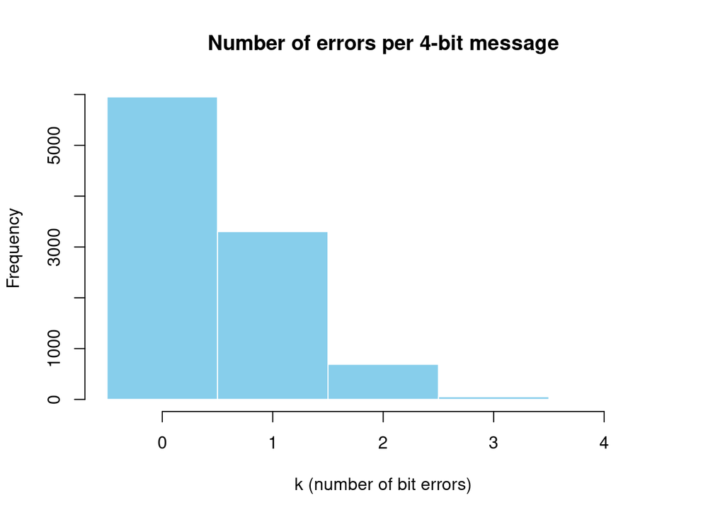

```r
K <- rbinom(N, size = 4, prob = p)

hist(K,
     breaks = seq(-0.5, 4.5, by = 1),
     col = "skyblue", border = "white",
     main = "Number of errors per 4-bit message",
     xlab = "k (number of bit errors)",
     ylab = "Frequency")
```

$$K \sim {Bin}(4, p)$$

### Task 2.

In this task, we discuss a real-life process that is well modelled by a Poisson distribution. As you remember, a Poisson random variable describes occurrences of rare events, i.e., counts the number of successes in a large number of independent random experiments. One of the typical examples is the **radioactive decay** process.

Consider a sample of radioactive element of mass $m$, which has a big *half-life period* $T$; it is vitally important to know the probability that during a one second period, the number of nuclei decays will not exceed some critical level $k$. This probability can easily be estimated using the fact that, given the *activity* ${\lambda}$ of the element (i.e., the probability that exactly one nucleus decays in one second) and the number $N$ of atoms in the sample, the random number of decays within a second is well modelled by Poisson distribution with parameter $\mu:=N\lambda$. Next, for the sample of mass $m$, the number of atoms is $N = \frac{m}{M} N_A$, where $N_A = 6 \times 10^{23}$ is the Avogadro constant, and $M$ is the molar (atomic) mass of the element. The activity of the element, $\lambda$, is $\log(2)/T$, where $T$ is measured in seconds.

Assume that a medical laboratory receives $n$ samples of radioactive element ${{}^{137}}\mathtt{Cs}$ (used in radiotherapy) with half-life period $T = 30.1$ years and mass $m = \mathtt{team\, id \,number} \times 10^{-6}$ g each. Denote by $X_1,X_2,\dots,X_n$ the **i.i.d. r.v.**’s counting the number of decays in sample $i$ in one second.

1. Specify the parameter of the Poisson distribution of $X_i$ (you’ll need the atomic mass of *Cesium-137*)
2. Show that the distribution of the sample means of $X_1,\dots,X_n$ gets very close to a normal one as $n$ becomes large and identify that normal distribution. To this end,
   - simulate the realization $x_1,x_2,\dots,x_n$ of the $X_i$ and calculate the sample mean $s=\overline{\mathbf{x}}$;
   - repeat this $K$ times to get the sample $\mathbf{s}=(s_1,\dots,s_K)$ of means and form the empirical cumulative distribution function $\hat F_{\mathbf{s}}$ of $\mathbf{s}$;
   - identify $\mu$ and $\sigma^2$ such that the $F$ of $\mathscr{N}(\mu,\sigma^2)$ is close to the $\hat F_{\mathbf{s}}$ and plot both **c.d.f.**’s on one graph to visualize their proximity (use the proper scales!);
   - calculate the maximal difference between the two ’s;
   - consider cases $n = 5$, $n = 10$, $n=50$ and comment on the results.
3. Calculate the largest possible value of $n$, for which the total number of decays in one second is less than $8 \times 10^8$ with probability at least $0.95$. To this end,
   - obtain the theoretical bound on $n$ using Markov inequality, Chernoff bound and Central Limit Theorem, and compare the results;
   - simulate the realization $x_1,x_2,\dots,x_n$ of the $X_i$ and calculate the sum $s=x_1 + \cdots +x_n$;
   - repeat this $K$ times to get the sample $\mathbf{s}=(s_1,\dots,s_K)$ of sums;
   - calculate the number of elements of the sample which are less than critical value ($8 \times 10^8$) and calculate the empirical probability; comment whether it is close to the desired level $0.95$

#### **Part 1: Calculate the Poisson parameter μ**

```r
# Physical constants and parameters for Cesium-137
# Half-life period in years
T_years <- 30.1
# Convert to seconds
T_seconds <- T_years * 365.25 * 24 * 3600
# Atomic mass of Cesium-137 (g/mol)
M <- 137
# Avogadro constant (atoms/mol)
N_A <- 6e23
# Mass of each sample in grams (id * 10^-6 g)
m <- id * 1e-6

# Calculate activity lambda: probability that one nucleus decays in one second
lambda <- log(2) / T_seconds

# Calculate number of atoms in one sample
N_atoms <- (m / M) * N_A

# Calculate Poisson parameter μ for one sample
mu <- N_atoms * lambda

cat("Poisson parameter μ for one sample:", mu, "\n")
```

```
## Poisson parameter μ for one sample: 38350138
```

```r
cat("This represents the expected number of decays per second in one sample.\n")
```

```
## This represents the expected number of decays per second in one sample.
```

#### **Part 2: Demonstrate convergence to normal distribution using CLT**

The Central Limit Theorem states that for i.i.d. random variables $X_1, X_2, \ldots, X_n$ with mean $\mu$ and variance $\sigma^2$, the sample mean $\bar{X}_n$ converges in distribution to $\mathscr{N}(\mu, \sigma^2/n)$ as $n \to \infty$.

For Poisson($\mu$), we have $\mathbb{E}[X_i] = \mu$ and $\text{Var}[X_i] = \mu$. Therefore, the sample mean should converge to $\mathscr{N}(\mu, \mu/n)$.

#### **Case n = 5**

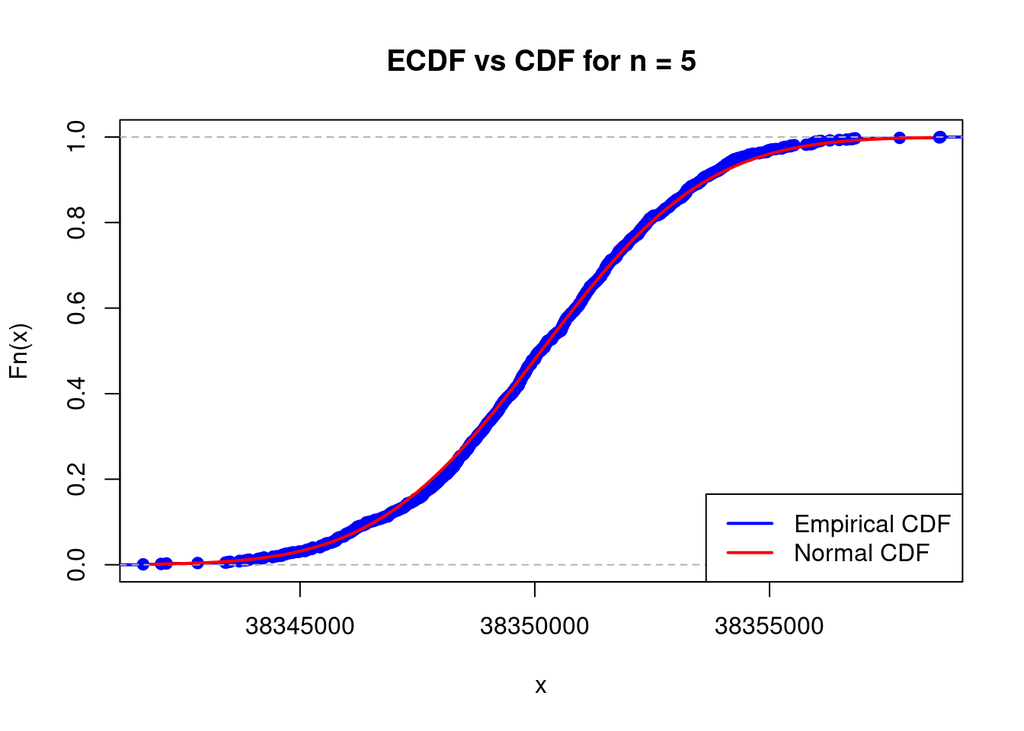

```r
# Number of simulations
K <- 1e3
# Sample size
n <- 5

# Simulate K sample means, each computed from n Poisson observations
sample_means_5 <- colMeans(matrix(rpois(n*K, lambda = mu), nrow=n))

# According to CLT, sample mean ~ N(mu, mu/n)
# Mean of the normal approximation
mu_normal_5 <- mu
# Standard deviation of the normal approximation
sigma_normal_5 <- sqrt(mu/n)

# Plot ecdf vs cdf
xlims_5 <- c(mu_normal_5 - 3*sigma_normal_5, mu_normal_5 + 3*sigma_normal_5)
Fs_5 <- ecdf(sample_means_5)

plot(Fs_5,
     xlim = xlims_5,
     ylim = c(0,1),
     col = "blue",
     lwd = 2,
     main = paste("ECDF vs CDF for n =", n))
curve(pnorm(x, mean = mu_normal_5, sd = sigma_normal_5),
      col = "red", lwd = 2, add = TRUE)
legend("bottomright",
       legend = c("Empirical CDF", "Normal CDF"),
       col = c("blue", "red"),
       lwd = 2)
```

```r
# Calculate maximal difference (Kolmogorov-Smirnov statistic)
# https://en.wikipedia.org/wiki/Kolmogorov%E2%80%93Smirnov_test
x_vals_5 <- sort(sample_means_5)
empirical_cdf_5 <- Fs_5(x_vals_5)
theoretical_cdf_5 <- pnorm(x_vals_5, mean = mu_normal_5, sd = sigma_normal_5)
max_diff_5 <- max(abs(empirical_cdf_5 - theoretical_cdf_5))

cat("For n =", n, ":\n")
```

```
## For n = 5 :
```

```r
cat("  Theoretical mean μ =", mu_normal_5, "\n")
```

```
##   Theoretical mean μ = 38350138
```

```r
cat("  Theoretical standard deviation σ =", sigma_normal_5, "\n")
```

```
##   Theoretical standard deviation σ = 2769.481
```

```r
cat("  Sample mean of sample means =", mean(sample_means_5), "\n")
```

```
##   Sample mean of sample means = 38350144
```

```r
cat("  Sample std dev of sample means =", sd(sample_means_5), "\n")
```

```
##   Sample std dev of sample means = 2682.822
```

```r
cat("  Maximum difference between ECDFs =", max_diff_5, "\n\n")
```

```
##   Maximum difference between ECDFs = 0.02191338
```

#### **Case n = 10**

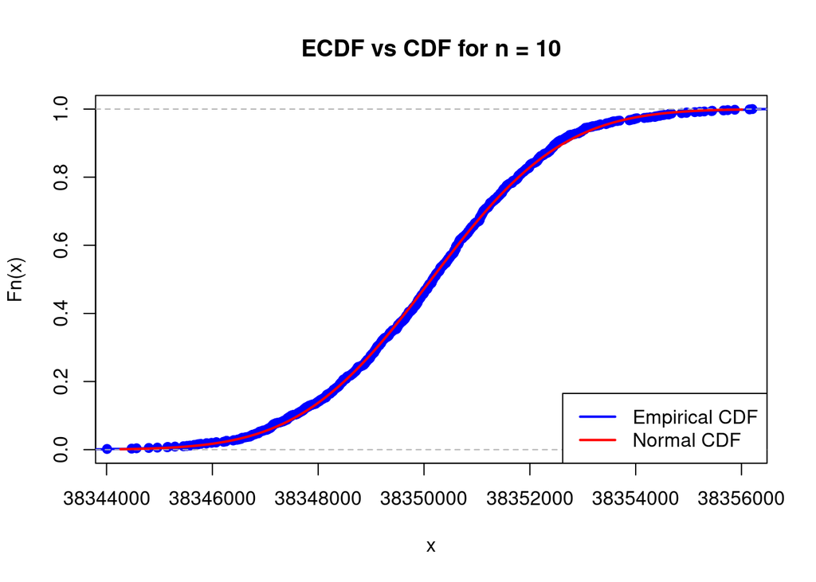

```r
# Sample size
n <- 10

# Simulate K sample means
sample_means_10 <- colMeans(matrix(rpois(n*K, lambda = mu), nrow=n))

# Normal approximation parameters
mu_normal_10 <- mu
sigma_normal_10 <- sqrt(mu/n)

# Plot ecdf vs cdf
xlims_10 <- c(mu_normal_10 - 3*sigma_normal_10, mu_normal_10 + 3*sigma_normal_10)
Fs_10 <- ecdf(sample_means_10)

plot(Fs_10,
     xlim = xlims_10,
     ylim = c(0,1),
     col = "blue",
     lwd = 2,
     main = paste("ECDF vs CDF for n =", n))
curve(pnorm(x, mean = mu_normal_10, sd = sigma_normal_10),
      col = "red", lwd = 2, add = TRUE)
legend("bottomright",
       legend = c("Empirical CDF", "Normal CDF"),
       col = c("blue", "red"),
       lwd = 2)
```

```r
# Calculate maximal difference
x_vals_10 <- sort(sample_means_10)
empirical_cdf_10 <- Fs_10(x_vals_10)
theoretical_cdf_10 <- pnorm(x_vals_10, mean = mu_normal_10, sd = sigma_normal_10)
max_diff_10 <- max(abs(empirical_cdf_10 - theoretical_cdf_10))

cat("For n =", n, ":\n")
```

```
## For n = 10 :
```

```r
cat("  Theoretical mean μ =", mu_normal_10, "\n")
```

```
##   Theoretical mean μ = 38350138
```

```r
cat("  Theoretical standard deviation σ =", sigma_normal_10, "\n")
```

```
##   Theoretical standard deviation σ = 1958.319
```

```r
cat("  Sample mean of sample means =", mean(sample_means_10), "\n")
```

```
##   Sample mean of sample means = 38350132
```

```r
cat("  Sample std dev of sample means =", sd(sample_means_10), "\n")
```

```
##   Sample std dev of sample means = 1979.232
```

```r
cat("  Maximum difference between ECDFs =", max_diff_10, "\n\n")
```

```
##   Maximum difference between ECDFs = 0.01649603
```